# Evaluating rules of thumb for selecting target seats

### Incorporate the 2019 notional results into the main dataframe

```python
# Bring the 2019 notional result variables into the main dataset, matching on match_ID (i.e. the unique campaign ID)

main_24_19 = main_24_cleaned.merge(r_19_long, how="inner", on="Match ID")
```

```python
# The new file should contain the same number of records as main_24_cleaned
# And should contain more columns equal to number of columns in r_19_long minus 1

print(main_24_cleaned.shape)
print(r_19_long.shape)
print(main_24_19.shape)
```

```
(1662, 13)
(4333, 10)
(1647, 22)
```

```python
# Since the resulting file was missing 15 rows, we need to run the merge again using left, then look for erroneous values.

main_24_19 = main_24_cleaned.merge(r_19_long, how="left", on="Match ID")
```

```python
# Check and count the data types in each column

for col in main_24_19.columns:
    print(main_24_19[col].apply(type).value_counts())
    print("- - -")
```

```
Match ID
<class 'str'>    1662
Name: count, dtype: int64
- - -
ONS ID
<class 'str'>    1662
Name: count, dtype: int64
- - -
Constituency name
<class 'str'>    1662
Name: count, dtype: int64
- - -
Region name
<class 'str'>    1662
Name: count, dtype: int64
- - -
Constituency type
<class 'str'>    1662
Name: count, dtype: int64
- - -
Party abbreviation_x
<class 'str'>    1662
Name: count, dtype: int64
- - -
Candidate gender
<class 'str'>    1662
Name: count, dtype: int64
- - -
Former MP
<class 'str'>    1662
Name: count, dtype: int64
- - -
votes_24
<class 'int'>    1662
Name: count, dtype: int64
- - -
share_24
<class 'float'>    1662
Name: count, dtype: int64
- - -
```

[output cut: 38 more lines]

```
<class 'float'>      15
Name: count, dtype: int64
- - -
position_19
<class 'float'>    1662
Name: count, dtype: int64
- - -
raw_diff_19
<class 'float'>    1662
Name: count, dtype: int64
- - -
pc_diff_19
<class 'float'>    1662
Name: count, dtype: int64
- - -
```

```python
# The above result shows 15 unexpected float values in 'ONS code'. Let's look at those values, with the components of match_ID:

main_filtered = main_24_19[[isinstance(value, float) for value in main_24_19['ONS code']]] # create filtered dataframe
main_filtered = main_filtered[['Constituency name', 'Match ID', 'ONS ID',  'Party abbreviation_x',
                               'ONS code', 'Party abbreviation_y']] # simplify debugging by showing only the relevant columns
main_filtered
```

|  | Constituency name | Match ID | ONS ID | Party abbreviation_x | ONS code | Party abbreviation_y |
| --- | --- | --- | --- | --- | --- | --- |
| 1568 | Ayr, Carrick and Cumnock | S14000107_Green | S14000107 | Green | NaN | NaN |
| 1569 | Ayr, Carrick and Cumnock | S14000107_LD | S14000107 | LD | NaN | NaN |
| 1570 | Ayr, Carrick and Cumnock | S14000107_Lab | S14000107 | Lab | NaN | NaN |
| 1571 | Berwickshire, Roxburgh and Selkirk | S14000108_Green | S14000108 | Green | NaN | NaN |
| 1572 | Berwickshire, Roxburgh and Selkirk | S14000108_LD | S14000108 | LD | NaN | NaN |
| 1573 | Berwickshire, Roxburgh and Selkirk | S14000108_Lab | S14000108 | Lab | NaN | NaN |
| 1574 | Central Ayrshire | S14000109_Green | S14000109 | Green | NaN | NaN |
| 1575 | Central Ayrshire | S14000109_LD | S14000109 | LD | NaN | NaN |
| 1576 | Central Ayrshire | S14000109_Lab | S14000109 | Lab | NaN | NaN |
| 1577 | Kilmarnock and Loudoun | S14000110_Green | S14000110 | Green | NaN | NaN |
| 1578 | Kilmarnock and Loudoun | S14000110_LD | S14000110 | LD | NaN | NaN |
| 1579 | Kilmarnock and Loudoun | S14000110_Lab | S14000110 | Lab | NaN | NaN |
| 1580 | West Aberdeenshire and Kincardine | S14000111_Green | S14000111 | Green | NaN | NaN |
| 1581 | West Aberdeenshire and Kincardine | S14000111_LD | S14000111 | LD | NaN | NaN |
| 1582 | West Aberdeenshire and Kincardine | S14000111_Lab | S14000111 | Lab | NaN | NaN |

```python
# We can see from the above that the apparent float values are actually NaNs ...
# .. which will have overwritten the blanks resulting from a mismatched match_id
# Manual review of the 2019 notional results CSV demonstrates that these five constituencies have incorrect ONS codes
# To fix this, I'll create a dictionary of the incorrect values and corrected values for ONS code:

correct_ONS = ['S14000107', 'S14000108', 'S14000109', 'S14000110', 'S14000111']
incorrect_ONS = ['S14000006', 'S14000008', 'S14000010', 'S14000040', 'S14000058']

ONS_corrections = dict(zip(incorrect_ONS, correct_ONS))
ONS_corrections
```

```
{'S14000006': 'S14000107',
 'S14000008': 'S14000108',
 'S14000010': 'S14000109',
 'S14000040': 'S14000110',
 'S14000058': 'S14000111'}
```

```python
# Now replace the incorrect values with the correct values in the r_19_long dataset

r_19_long['ONS code'] = r_19_long['ONS code'].replace(ONS_corrections)
```

```python
#Let's check that the change has worked:

r_19_long[r_19_long['ONS code'] == 'S14000107']
```

|  | Match ID | ONS code | winner_19 | total_votes_19 | max_votes_19 | Party abbreviation | votes_19 | position_19 | raw_diff_19 | pc_diff_19 |
| --- | --- | --- | --- | --- | --- | --- | --- | --- | --- | --- |
| 19 | S14000006_Con | S14000107 | SNP | 46592 | 20272.0 | Con | 17943 | 2.0 | 2329.0 | 0.049987 |
| 638 | S14000006_Lab | S14000107 | SNP | 46592 | 20272.0 | Lab | 6219 | 3.0 | 14053.0 | 0.301618 |
| 1257 | S14000006_LD | S14000107 | SNP | 46592 | 20272.0 | LD | 2158 | 4.0 | 18114.0 | 0.388779 |
| 1876 | S14000006_Brx | S14000107 | SNP | 46592 | 20272.0 | Brx | 0 | 5.0 | 20272.0 | 0.435096 |
| 2495 | S14000006_Green | S14000107 | SNP | 46592 | 20272.0 | Green | 0 | 5.0 | 20272.0 | 0.435096 |
| 3114 | S14000006_SNP | S14000107 | SNP | 46592 | 20272.0 | SNP | 20272 | 1.0 | 0.0 | 0.0 |
| 3733 | S14000006_All other candidates | S14000107 | SNP | 46592 | 20272.0 | All other candidates | 0 | 5.0 | 20272.0 | 0.435096 |

```python
# Now let's recreate the match_id using the new ONS code:
r_19_long['Match ID'] = r_19_long['ONS code'] + "_" + r_19_long['Party abbreviation']
```

```python
# And let's check to see that we have a row with one of the missing match IDs:

r_19_long[r_19_long['Match ID'] == 'S14000107_Green']
```

|  | Match ID | ONS code | winner_19 | total_votes_19 | max_votes_19 | Party abbreviation | votes_19 | position_19 | raw_diff_19 | pc_diff_19 |
| --- | --- | --- | --- | --- | --- | --- | --- | --- | --- | --- |
| 2495 | S14000107_Green | S14000107 | SNP | 46592 | 20272.0 | Green | 0 | 5.0 | 20272.0 | 0.435096 |

```python
# Now we'll run the merge using 'inner' again and check that it produces 1662 rows.

main_24_19 = main_24_cleaned.merge(r_19_long, how="inner", on="Match ID")
print(main_24_cleaned.shape)
print(r_19_long.shape)
print(main_24_19.shape)
```

```
(1662, 13)
(4333, 10)
(1662, 22)
```

```python
# Success!
```

```python
# Time to check the resulting dataframe
main_24_19.info()
```

```
<class 'pandas.core.frame.DataFrame'>
RangeIndex: 1662 entries, 0 to 1661
Data columns (total 22 columns):
 #   Column                  Non-Null Count  Dtype
---  ------                  --------------  -----
 0   Match ID                1662 non-null   object
 1   ONS ID                  1662 non-null   object
 2   Constituency name       1662 non-null   object
 3   Region name             1662 non-null   object
 4   Constituency type       1662 non-null   object
 5   Party abbreviation_x    1662 non-null   object
 6   Candidate gender        1662 non-null   object
 7   Former MP               1662 non-null   object
 8   votes_24                1662 non-null   int64
 9   share_24                1662 non-null   float64
 10  valid_votes_24          1662 non-null   int64
 11  credible_candidates_24  1662 non-null   int64
 12  won_24                  1662 non-null   int64
 13  ONS code                1662 non-null   object
 14  winner_19               1662 non-null   object
 15  total_votes_19          1662 non-null   object
 16  max_votes_19            1662 non-null   float64
 17  Party abbreviation_y    1662 non-null   object
 18  votes_19                1662 non-null   object
 19  position_19             1662 non-null   float64
 20  raw_diff_19             1662 non-null   object
 21  pc_diff_19              1662 non-null   object
dtypes: float64(3), int64(4), object(15)
memory usage: 285.8+ KB
```

```python
# Check columns to see that only 'ONS ID'/'ONS code' and 'Party Abbreviation' are repeated
main_24_19.columns
```

```
Index(['Match ID', 'ONS ID', 'Constituency name', 'Region name',
       'Constituency type', 'Party abbreviation_x', 'Candidate gender',
       'Former MP', 'votes_24', 'share_24', 'valid_votes_24',
       'credible_candidates_24', 'won_24', 'ONS code', 'winner_19',
       'total_votes_19', 'max_votes_19', 'Party abbreviation_y', 'votes_19',
       'position_19', 'raw_diff_19', 'pc_diff_19'],
      dtype='object')
```

```python
# Add columns to check that ONS ID / ONS code and 'Party Abbreviation' match across the datasets

main_24_19['Check ONS ID'] = np.where(main_24_19['ONS ID'] == main_24_19['ONS code'], 1, 0)
main_24_19['Check Party Abbreviation'] = np.where(main_24_19['Party abbreviation_x'] == main_24_19['Party abbreviation_y'], 1, 0)
```

```python
# Print % of matching values

print("ONS Match:", main_24_19['Check ONS ID'].sum() / len(main_24_19) * 100, "%")

print("Party Match:", main_24_19['Check Party Abbreviation'].sum() / len(main_24_19) * 100, "%")
```

```
ONS Match: 100.0 %
Party Match: 100.0 %
```

```python
# Remove check columns and repeated columns

main_24_19_cleaned = main_24_19.drop(['ONS code', 'Party abbreviation_y', 'Check ONS ID', 'Check Party Abbreviation'], axis = 1)
```

```python
# Rename '_x' columns to exclude that suffix

main_24_19_cleaned.rename(columns = {'Party abbreviation_x':'Party abbreviation'}, inplace=True)
```

```python
# Check the dataframe
main_24_19_cleaned.info()
```

```
<class 'pandas.core.frame.DataFrame'>
RangeIndex: 1662 entries, 0 to 1661
Data columns (total 20 columns):
 #   Column                  Non-Null Count  Dtype
---  ------                  --------------  -----
 0   Match ID                1662 non-null   object
 1   ONS ID                  1662 non-null   object
 2   Constituency name       1662 non-null   object
 3   Region name             1662 non-null   object
 4   Constituency type       1662 non-null   object
 5   Party abbreviation      1662 non-null   object
 6   Candidate gender        1662 non-null   object
 7   Former MP               1662 non-null   object
 8   votes_24                1662 non-null   int64
 9   share_24                1662 non-null   float64
 10  valid_votes_24          1662 non-null   int64
 11  credible_candidates_24  1662 non-null   int64
 12  won_24                  1662 non-null   int64
 13  winner_19               1662 non-null   object
 14  total_votes_19          1662 non-null   object
 15  max_votes_19            1662 non-null   float64
 16  votes_19                1662 non-null   object
 17  position_19             1662 non-null   float64
 18  raw_diff_19             1662 non-null   object
 19  pc_diff_19              1662 non-null   object
dtypes: float64(3), int64(4), object(13)
memory usage: 259.8+ KB
```

### Clean and standardise the StopTheTories.vote target seat data

```python
# Ingest StopTheTories.vote target seat data

StopTheTories = pd.read_csv('data/20240630_2122-Stop-The-Tories .csv')
```

```python
# Check columns to identify target seat data

StopTheTories.columns
```

```
Index(['Short Code', 'Name', 'Country', 'Implied Vote Share: Winner',
       'Implied Vote Share: Biggest Progressive Party',
       'Implied Vote Share: Con', 'Implied Vote Share: Lab',
       'Implied Vote Share: LD', 'Implied Vote Share: Green',
       'Implied Vote Share: Reform', 'Implied Vote Share: SNP',
       'Implied Vote Share: PC', 'Implied Vote Share: Tot oths',
       'Implied Vote Share: Other', 'Implied Raw: non-voter',
       'Implied Raw: electorate', 'Implied Raw: Conv', 'Implied Raw: Labv',
       'Implied Raw: LDv', 'Implied Raw: Grnv', 'Implied Raw: Brxv',
       'Implied Raw: SNPv', 'Implied Raw: PCv', 'Implied Raw: TotOthv',
       'MRP Vote Share Winner', 'MRP Vote Share Biggest Progressive Party',
       'MRP Vote Share Con', 'MRP Vote Share Lab', 'MRP Vote Share LD',
       'MRP Vote Share Green', 'MRP Vote Share SNP', 'MRP Vote Share PC',
       'MRP Vote Share Reform', 'MRP Vote Share Other', 'Green Target',
       'Labour Non-Target', 'Labour Volunteer Target', 'Lib Dem Top 80 MRP',
       'TV Advice', 'Manual TV Explanation', 'Manual TV Explanation Source',
       'Region', 'GSS Code'],
      dtype='object')
```

```python
StopTheTories = StopTheTories[['Name', 'Country', 'Green Target', 'Labour Volunteer Target', 'Lib Dem Top 80 MRP']]
```

```python
StopTheTories.columns
```

```
Index(['Name', 'Country', 'Green Target', 'Labour Volunteer Target',
       'Lib Dem Top 80 MRP'],
      dtype='object')
```

```python
StopTheTories.shape
```

```
(650, 5)
```

```python
StopTheTories['Country'].unique()
```

```
array(['Wales', 'Scotland', 'England', 'Northern Ireland'], dtype=object)
```

```python
# Remove constituencies in Northern Ireland

StopTheTories = StopTheTories[StopTheTories['Country'] != 'Northern Ireland']
```

```python
# Check that 18 rows have been removed

StopTheTories.shape
```

```
(632, 5)
```

```python
# Remove the speaker's constituency

StopTheTories = StopTheTories[StopTheTories['Name'] != 'Chorley']
```

```python
# Check that 1 row has been removed

StopTheTories.shape
```

```
(631, 5)
```

```python
# Remove the constituencies where by-elections were held

# First identify the index numbers of rows containing campaigns in those constituencies:

by_election_rows = StopTheTories[StopTheTories['Name'].isin(by_elections)].index

# Then drop those rows:

StopTheTories = StopTheTories.drop(by_election_rows)

# And check that the sheet is now 12 rows shorter

StopTheTories.shape

# As noted above, there were in fact 23 by-elections in the period, but the re-naming of constituencies ...
# ... means that I have so far only been able to identify 12 2024 constituencies which had by-elections
# This will need to be borne in mind when interpreting the results.
```

```
(619, 5)
```

```python
# Convert the target seat columns into binary values

# First reveal the values in the relevant columns

print(StopTheTories['Green Target'].unique())
print(StopTheTories['Labour Volunteer Target'].unique())
print(StopTheTories['Lib Dem Top 80 MRP'].unique())
```

```
[nan True]
[nan 'Target']
[nan 73. 74.  6. 63. 20. 70. 53. 13. 56.  1. 31. 37. 25. 43. 65.  7. 10.
 79. 71. 42. 44. 55. 61. 23. 28. 24. 51. 21. 29. 26. 52. 62.  5. 14. 58.
 35. 38. 59. 64. 32. 36. 78. 48. 33. 76. 41. 16.  9.  2. 68. 77. 66. 80.
 15. 39. 46. 72. 67. 69. 47.  3. 22. 19. 34. 75. 45. 57. 54.  4.  8. 12.
 40. 27. 11. 49. 50. 17. 18.]
```

```python
# With some help from ChatGPT, create a function to convert numbers in 'Lib Dem Top 80 MRP' into 1s and blanks into 0s

def numeric_to_binary(value):
    if pd.isna(value):  # Check for NaN
        return 0
    if isinstance(value, (int, float)):  # Check for numeric types
        return 1
    try:
        # Try converting string to a number
        float(value)
        return 1
    except (ValueError, TypeError):
        return 0


# Then run the function on the 'Lib Dem Top 80 MRP' column:

StopTheTories['Lib Dem Top 80 MRP'] = StopTheTories['Lib Dem Top 80 MRP'].apply(numeric_to_binary)

# And check the resulting values:

print(StopTheTories['Lib Dem Top 80 MRP'].unique())
```

```
[0 1]
```

```python
# Then create a dictionary for the changes

changes = {'Target' : 1, True : 1, math.nan : 0, '' : 0, 0 : 0}

# Finally run the changes, and save them into columns named for the party abbreviations ...
# ... So we can easily merge the resulting data with our main dataframe.

StopTheTories['Green'] = StopTheTories['Green Target'].replace(changes).astype(int)
StopTheTories['Lab'] = StopTheTories['Labour Volunteer Target'].replace(changes).astype(int)
StopTheTories['LD'] = StopTheTories['Lib Dem Top 80 MRP'].replace(changes).astype(int)
```

```python
# check the resulting values - we want them all to be 0s and 1s.

print(StopTheTories['Green'].unique())
print(StopTheTories['Lab'].unique())
print(StopTheTories['LD'].unique())
```

```
[0 1]
[0 1]
[0 1]
```

```python
# Now check the sums of each column. We're looking for something no more than 4 Green targets ...
# ... 161 Labour targets and 80 Lib Dem targets. (The actual numbers will be lower owing to the ...
# ... constituencies removed, such as for by-elections.

print(StopTheTories['Green'].sum())
print(StopTheTories['Lab'].sum())
print(StopTheTories['LD'].sum())
```

```
4
157
78
```

```python
# Remove all columns not needed for the match

StopTheTories= StopTheTories[['Name', 'Green', 'Lab', 'LD']]
```

```python
# Rename the 'name' column as 'Constituency name'
# Note that this dataset uses a different format of constituency ID, but we can match on constituency name instead

StopTheTories.rename(columns={'Name':'Constituency name'}, inplace=True)
```

```python
# Melt the data into long format, such that it indicates for each combination of constituency ....
# ... and party whether that party had targetted that seat (as a binary value)


StopTheTories_long = StopTheTories.melt(id_vars='Constituency name', value_vars=['Green', 'Lab', 'LD'], var_name='Party abbreviation', value_name='target_24')
```

```python
# Check the shape of the dataframe. We're looking for one that is (619 * 3) = 1857 rows long, and 3 columns wide
StopTheTories_long.shape
```

```
(1857, 3)
```

```python
# Hurray! Now let's look at the dataframe just for the satisfaction of it.

StopTheTories_long
```

|  | Constituency name | Party abbreviation | target_24 |
| --- | --- | --- | --- |
| 0 | Alyn and Deeside | Green | 0 |
| 1 | Alloa and Grangemouth | Green | 0 |
| 2 | Arbroath and Broughty Ferry | Green | 0 |
| 3 | Aldridge-Brownhills | Green | 0 |
| 4 | Argyll, Bute and South Lochaber | Green | 0 |
| ... | ... | ... | ... |
| 1852 | Wythenshawe and Sale East | LD | 0 |
| 1853 | Yeovil | LD | 1 |
| 1854 | Ynys Môn | LD | 0 |
| 1855 | York Central | LD | 0 |
| 1856 | York Outer | LD | 0 |

1857 rows × 3 columns

```python
# Smashing. Now create a new matching variable, 'Match name':

StopTheTories_long['Match name'] = StopTheTories_long['Constituency name'] + "_" + StopTheTories_long['Party abbreviation']

StopTheTories_long
```

|  | Constituency name | Party abbreviation | target_24 | Match name |
| --- | --- | --- | --- | --- |
| 0 | Alyn and Deeside | Green | 0 | Alyn and Deeside_Green |
| 1 | Alloa and Grangemouth | Green | 0 | Alloa and Grangemouth_Green |
| 2 | Arbroath and Broughty Ferry | Green | 0 | Arbroath and Broughty Ferry_Green |
| 3 | Aldridge-Brownhills | Green | 0 | Aldridge-Brownhills_Green |
| 4 | Argyll, Bute and South Lochaber | Green | 0 | Argyll, Bute and South Lochaber_Green |
| ... | ... | ... | ... | ... |
| 1852 | Wythenshawe and Sale East | LD | 0 | Wythenshawe and Sale East_LD |
| 1853 | Yeovil | LD | 1 | Yeovil_LD |
| 1854 | Ynys Môn | LD | 0 | Ynys Môn_LD |
| 1855 | York Central | LD | 0 | York Central_LD |
| 1856 | York Outer | LD | 0 | York Outer_LD |

1857 rows × 4 columns

```python
# Check the number of unique values per column in the resulting data.
# We're expecting 619 constituencies, 3 parties, 2 values for 'Target' and 1857 unique match names

StopTheTories_long.nunique()
```

```
Constituency name      619
Party abbreviation       3
target_24                2
Match name            1857
dtype: int64
```

### Incorporate the StopTheTories.vote target seat data

```python
# Create the 'match name' variable in the main dataframe, so we can successfully run a merge

main_24_19_cleaned['Match name'] = main_24_19_cleaned['Constituency name'] + "_" + main_24_19_cleaned['Party abbreviation']
```

```python
# Bring the target seat variables into the main dataset, matching on constituency names (since this dataset doesn't use the same IDs)

main_24_19_STTV = main_24_19_cleaned.merge(StopTheTories_long, how="inner", on="Match name")
```

```python
# The new file should contain the same number of records as main_24_19_cleaned
# And should contain more columns equal to number of columns in StopTheTories_long minus 1

print(main_24_19_cleaned.shape)
print(StopTheTories_long.shape)
print(main_24_19_STTV.shape)
```

```
(1662, 21)
(1857, 4)
(1662, 24)
```

```python
main_24_19_STTV
```

|  | Match ID | ONS ID | Constituency name_x | Region name | Constituency type | Party abbreviation_x | Candidate gender | Former MP | votes_24 | share_24 | ... | total_votes_19 | max_votes_19 | votes_19 | position_19 | raw_diff_19 | pc_diff_19 | Match name | Constituency name_y | Party abbreviation_y | target_24 |
| --- | --- | --- | --- | --- | --- | --- | --- | --- | --- | --- | --- | --- | --- | --- | --- | --- | --- | --- | --- | --- | --- |
| 0 | E14001063_Green | E14001063 | Aldershot | South East | Borough | Green | Male | No | 2155 | 0.044393 | ... | 51828 | 29453.0 | 1839 | 4.0 | 27614.0 | 0.532801 | Aldershot_Green | Aldershot | Green | 0 |
| 1 | E14001063_LD | E14001063 | Aldershot | South East | Borough | LD | Male | No | 4052 | 0.083471 | ... | 51828 | 29453.0 | 9068 | 3.0 | 20385.0 | 0.39332 | Aldershot_LD | Aldershot | LD | 0 |
| 2 | E14001063_Lab | E14001063 | Aldershot | South East | Borough | Lab | Female | No | 19764 | 0.407136 | ... | 51828 | 29453.0 | 11468 | 2.0 | 17985.0 | 0.347013 | Aldershot_Lab | Aldershot | Lab | 1 |
| 3 | E14001064_Green | E14001064 | Aldridge-Brownhills | West Midlands | Borough | Green | Female | No | 1746 | 0.042677 | ... | 47321 | 32941.0 | 873 | 4.0 | 32068.0 | 0.67767 | Aldridge-Brownhills_Green | Aldridge-Brownhills | Green | 0 |
| 4 | E14001064_LD | E14001064 | Aldridge-Brownhills | West Midlands | Borough | LD | Male | No | 1755 | 0.042897 | ... | 47321 | 32941.0 | 2654 | 3.0 | 30287.0 | 0.640033 | Aldridge-Brownhills_LD | Aldridge-Brownhills | LD | 0 |
| ... | ... | ... | ... | ... | ... | ... | ... | ... | ... | ... | ... | ... | ... | ... | ... | ... | ... | ... | ... | ... | ... |
| 1657 | W07000111_LD | W07000111 | Wrexham | Wales | County | LD | Male | No | 1777 | 0.044015 | ... | 47123 | 21933.0 | 2013 | 3.0 | 19920.0 | 0.422724 | Wrexham_LD | Wrexham | LD | 0 |
| 1658 | W07000111_Lab | W07000111 | Wrexham | Wales | County | Lab | Male | No | 15836 | 0.392242 | ... | 47123 | 21933.0 | 17994 | 2.0 | 3939.0 | 0.08359 | Wrexham_Lab | Wrexham | Lab | 1 |
| 1659 | W07000112_Green | W07000112 | Ynys Môn | Wales | County | Green | Male | No | 604 | 0.018512 | ... | 36552 | 12959.0 | 0 | 4.0 | 12959.0 | 0.354536 | Ynys Môn_Green | Ynys Môn | Green | 0 |
| 1660 | W07000112_LD | W07000112 | Ynys Môn | Wales | County | LD | Female | No | 439 | 0.013455 | ... | 36552 | 12959.0 | 0 | 4.0 | 12959.0 | 0.354536 | Ynys Môn_LD | Ynys Môn | LD | 0 |
| 1661 | W07000112_Lab | W07000112 | Ynys Môn | Wales | County | Lab | Male | No | 7619 | 0.233511 | ... | 36552 | 12959.0 | 10991 | 2.0 | 1968.0 | 0.053841 | Ynys Môn_Lab | Ynys Môn | Lab | 1 |

1662 rows × 24 columns

```python
#Show columns to check that only 'Constituency name' and 'Party abbreviation' are repeated
main_24_19_STTV.columns
```

```
Index(['Match ID', 'ONS ID', 'Constituency name_x', 'Region name',
       'Constituency type', 'Party abbreviation_x', 'Candidate gender',
       'Former MP', 'votes_24', 'share_24', 'valid_votes_24',
       'credible_candidates_24', 'won_24', 'winner_19', 'total_votes_19',
       'max_votes_19', 'votes_19', 'position_19', 'raw_diff_19', 'pc_diff_19',
       'Match name', 'Constituency name_y', 'Party abbreviation_y',
       'target_24'],
      dtype='object')
```

```python
# Add columns to check that ONS ID / ONS code and 'Party Abbreviation' match across the datasets

main_24_19_STTV['Check Constituency Name'] = np.where(main_24_19_STTV['Constituency name_y'] == main_24_19_STTV['Constituency name_x'], 1, 0)
main_24_19_STTV['Check Party Abbreviation'] = np.where(main_24_19_STTV['Party abbreviation_x'] == main_24_19_STTV['Party abbreviation_y'], 1, 0)
```

```python
# Print % of matching values

print("Name Match:", main_24_19_STTV['Check Constituency Name'].sum() / len(main_24_19_STTV) * 100, "%")

print("Party Match:", main_24_19_STTV['Check Party Abbreviation'].sum() / len(main_24_19_STTV) * 100, "%")
```

```
Name Match: 100.0 %
Party Match: 100.0 %
```

```python
# Remove 'Match name', check columns and _y columns

main_24_19_STTV_cleaned = main_24_19_STTV.drop(columns=['Check Constituency Name', 'Check Party Abbreviation',
                                                        'Constituency name_y', 'Party abbreviation_y', 'Match name'])
```

```python
# Tidy up the '_x' columns

main_24_19_STTV_cleaned.rename(columns={'Constituency name_x':'Constituency name',
                                        'Party abbreviation_x':'Party abbreviation'}, inplace=True)
```

```python
# Check the resulting columns

main_24_19_STTV_cleaned.columns
```

```
Index(['Match ID', 'ONS ID', 'Constituency name', 'Region name',
       'Constituency type', 'Party abbreviation', 'Candidate gender',
       'Former MP', 'votes_24', 'share_24', 'valid_votes_24',
       'credible_candidates_24', 'won_24', 'winner_19', 'total_votes_19',
       'max_votes_19', 'votes_19', 'position_19', 'raw_diff_19', 'pc_diff_19',
       'target_24'],
      dtype='object')
```

```python
# Rename as something more snappy!

main_final = main_24_19_STTV_cleaned
```

### Perform checks on the final dataframe

```python
# Check the shape of the dataframe. We're expecting 1662 rows and 21 columns.

main_final.shape
```

```
(1662, 21)
```

```python
# List the columns
main_final.columns
```

```
Index(['Match ID', 'ONS ID', 'Constituency name', 'Region name',
       'Constituency type', 'Party abbreviation', 'Candidate gender',
       'Former MP', 'votes_24', 'share_24', 'valid_votes_24',
       'credible_candidates_24', 'won_24', 'winner_19', 'total_votes_19',
       'max_votes_19', 'votes_19', 'position_19', 'raw_diff_19', 'pc_diff_19',
       'target_24'],
      dtype='object')
```

```python
# We no longer need the variables that were used to calculate the dependent and indpedent variables, so we can drop those.
# We also no longer need the constituency names column

columns_to_drop = ['Constituency name', 'votes_24', 'valid_votes_24', 'total_votes_19', 'max_votes_19', 'votes_19']

main_final.drop(columns=columns_to_drop, inplace=True)
```

```python
# Tidy up remaining column names

main_final.rename(columns={'Match ID':'campaign_ID', 'ONS ID':'constituency_ID', 'Region name':'region_name', 'Constituency type':'constituency_type',
                           'Party abbreviation':'party', 'Candidate gender':'candidate_gender', 'Former MP':'former_mp'}, inplace=True)
```

```python
# Re-list the columns
main_final.columns
```

```
Index(['campaign_ID', 'constituency_ID', 'region_name', 'constituency_type',
       'party', 'candidate_gender', 'former_mp', 'share_24',
       'credible_candidates_24', 'won_24', 'winner_19', 'position_19',
       'raw_diff_19', 'pc_diff_19', 'target_24'],
      dtype='object')
```

```python
# Check the unique values of all control variables
# We're expecting to see 11 regions, 2 constituency types, 3 parties, 3 genders, binary values for 'former_mp' and 'target_24' ...
# ... and values in the region of 5 to 9 for winner_19 and credible_candidates_24

# First, make a list of the control variables
controls = ['region_name', 'constituency_type', 'party', 'candidate_gender', 'former_mp', 'credible_candidates_24', 'winner_19', 'target_24']

# Then show the unique values of each.

main_final[controls].nunique()
```

```
region_name               11
constituency_type          2
party                      3
candidate_gender           3
former_mp                  2
credible_candidates_24     5
winner_19                  6
target_24                  2
dtype: int64
```

```python
# Check the unique values of the one categorical dependent variable, 'position_19'

main_final['position_19'].nunique()
```

```
7
```

```python
# Seven is suspiciously high if we've removed all first place candidates. Few constituencies would have this many candidates.
# Let's take a look at the values.

main_final['position_19'].value_counts()
```

```
position_19
3.0    472
4.0    461
2.0    382
5.0    245
6.0     59
1.0     41
7.0      2
Name: count, dtype: int64
```

```python
# 41 campaigns starting from 1st place. We removed sitting MPs earlier, but we didn't check for retiring MPs.
# These constituencies will be ones where MPs retired, and a new candidate from the their party contests the seat.
# We should still exclude these, because we're looking to understand which seats should be targetted by a non-incumbent parties
# (As opposed to non-incumbent candidates.)

main_final = main_final[main_final['position_19'] != 1.0]
main_final['position_19'].value_counts()
```

```
position_19
3.0    472
4.0    461
2.0    382
5.0    245
6.0     59
7.0      2
Name: count, dtype: int64
```

```python
# After that deletion, we should still have 619 constituencies. Let's check.

main_final['constituency_ID'].nunique()
```

```
619
```

```python
main_final.info()
```

```
<class 'pandas.core.frame.DataFrame'>
Index: 1621 entries, 0 to 1661
Data columns (total 15 columns):
 #   Column                  Non-Null Count  Dtype
---  ------                  --------------  -----
 0   campaign_ID             1621 non-null   object
 1   constituency_ID         1621 non-null   object
 2   region_name             1621 non-null   object
 3   constituency_type       1621 non-null   object
 4   party                   1621 non-null   object
 5   candidate_gender        1621 non-null   object
 6   former_mp               1621 non-null   object
 7   share_24                1621 non-null   float64
 8   credible_candidates_24  1621 non-null   int64
 9   won_24                  1621 non-null   int64
 10  winner_19               1621 non-null   object
 11  position_19             1621 non-null   float64
 12  raw_diff_19             1621 non-null   object
 13  pc_diff_19              1621 non-null   object
 14  target_24               1621 non-null   int64
dtypes: float64(2), int64(3), object(10)
memory usage: 202.6+ KB
```

```python
# Also, we can see the wrong datatype on two of the independent variables.

main_final['raw_diff_19'] = pd.to_numeric(main_final['raw_diff_19'], errors='coerce')
main_final['pc_diff_19'] = pd.to_numeric(main_final['pc_diff_19'], errors='coerce')
```

```python
# All looks good, but we need to reset the index, then we should be done:
main_final = main_final.reset_index(drop=True)

main_final.info()
```

```
<class 'pandas.core.frame.DataFrame'>
RangeIndex: 1621 entries, 0 to 1620
Data columns (total 15 columns):
 #   Column                  Non-Null Count  Dtype
---  ------                  --------------  -----
 0   campaign_ID             1621 non-null   object
 1   constituency_ID         1621 non-null   object
 2   region_name             1621 non-null   object
 3   constituency_type       1621 non-null   object
 4   party                   1621 non-null   object
 5   candidate_gender        1621 non-null   object
 6   former_mp               1621 non-null   object
 7   share_24                1621 non-null   float64
 8   credible_candidates_24  1621 non-null   int64
 9   won_24                  1621 non-null   int64
 10  winner_19               1621 non-null   object
 11  position_19             1621 non-null   float64
 12  raw_diff_19             1621 non-null   float64
 13  pc_diff_19              1621 non-null   float64
 14  target_24               1621 non-null   int64
dtypes: float64(4), int64(3), object(8)
memory usage: 190.1+ KB
```

## Description & Visualisation of Resulting Dataset

### Description

As a reminder, we have 619 constituencies in scope, with either 2 or 3 campaigns in each, for a total of 1621 campaigns.

Our columns are as follows:

```python
main_final.columns
```

```
Index(['campaign_ID', 'constituency_ID', 'region_name', 'constituency_type',
       'party', 'candidate_gender', 'former_mp', 'share_24',
       'credible_candidates_24', 'won_24', 'winner_19', 'position_19',
       'raw_diff_19', 'pc_diff_19', 'target_24'],
      dtype='object')
```

The dependent variables are 'won_24' and 'share_24'

- 'won_24' is a binary variable indicating whether or not the party won the constituency
- 'share_24' is the percentage of the votes won by that party

Our three independent variables of interest are: 'position_19', 'raw_diff_19', and 'pc_diff_19'.

- 'position_19' is the ranked position achieved in the constituency, where 1 is the highest
- 'raw_diff_19' is the difference between the winner's votes won and the party's votes won (which will be 0 if the party won)
- 'pc_diff_19' is the same difference expressed in percentage terms

```python
# Our eight control variables are as follows:
controls
```

```
['region_name',
 'constituency_type',
 'party',
 'candidate_gender',
 'former_mp',
 'credible_candidates_24',
 'winner_19',
 'target_24']
```

Those control variables are mostly self-explanatory. Those worth clarifying are:

- 'constituency_type' is either 'Borough' (i.e. urban) or 'County' (i.e. rural)
- 'credible_candidates_24' is the number of candidates who won more than 5% of the vote (thus keeping their deposit)
- 'winner_19' is which political party won the constituency in 2019
- 'target_24' indicates whether the party targetted that constituency in their campaign (i.e. invested time and resources)

```python
# Show plot of 2019 position vs 2024 position, per campaign


# Describe visualised relationship (association, correlation, outliers)
```

[output not shown]

### Visualisations of Outcome Variables

#### Distribution of win/loss outcomes across all campaigns

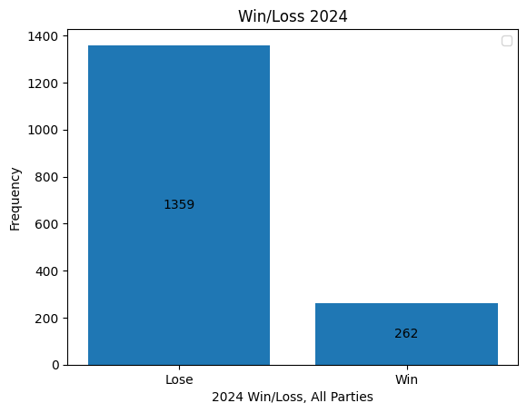

```python
# First, let's show our outcome variables, so we know what distributions we're working with.

# Distribution of 'won_24'
wins = main_final.groupby(['won_24']).size()
wins_bar = plt.bar(wins.index, wins.values)
plt.bar_label(wins_bar, label_type='center')

plt.xlabel('2024 Win/Loss, All Parties')
plt.xticks(ticks=[0, 1], labels=['Lose', 'Win']) # make binary values intelligible
plt.ylabel('Frequency')
plt.title('Win/Loss 2024')
plt.legend()
```

#### Distribution of vote share outcomes across all campaigns

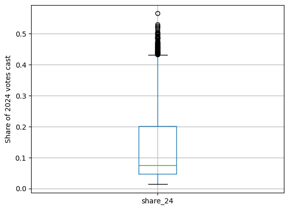

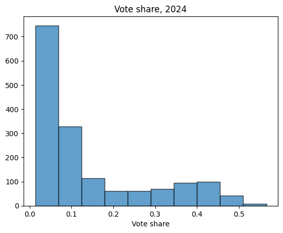

```python
# Create a boxplot for the 'share_24' variable
main_final.boxplot(column='share_24')
plt.ylabel('Share of 2024 votes cast')
plt.show()

# Create a histogram showing the same data
plt.hist(main_final['share_24'], bins=10, edgecolor='black', alpha=0.7)
plt.title('Vote share, 2024')
plt.xlabel('Vote share')
plt.show()
```

### Visualisations of Selected Outcome-Control Associations

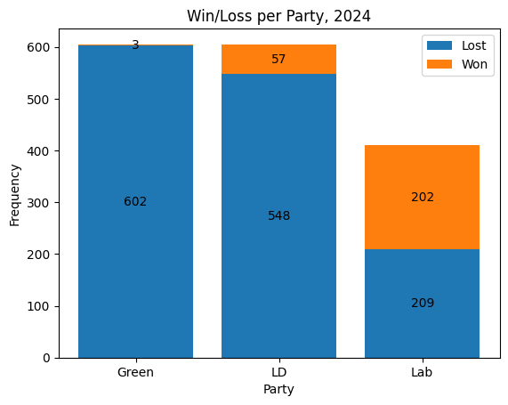

```python
# Now to show wins by party.
wins_per_party = main_final.groupby(['party', 'won_24']).size().unstack(fill_value=0) # create temporary dataframe

# Create a stacked bar chart
x = wins_per_party.index  # i.e. x = Party names
bar1 = plt.bar(x, wins_per_party[0], label='Lost')  # Bottom stack = lost
bar2 = plt.bar(x, wins_per_party[1], bottom=wins_per_party[0], label='Won')  # Top stack = won

# Add labels
plt.bar_label(bar1, label_type='center')
plt.bar_label(bar2, label_type='center')
plt.xlabel('Party')
plt.ylabel('Frequency')
plt.title('Win/Loss per Party, 2024')
plt.legend()

# Show the plot
plt.show()
```

Given the above, we can expect political party (the 'party' variable) to have strong explanatory power over the 'won_24' variable. Labour won 49% of the campaigns in this dataset, while the Greens won less thatn 1%.

Note that the number of campaigns for Labour is low because we removed all incumbent MPs and all candidates standing in seats vacated by retiring MPs. Labour had more seats than LDs or Greens, so we see fewer of their campaigns in this dataset.

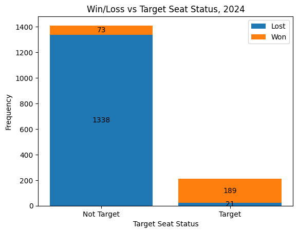

```python
# Now to show wins by target seat status.
wins_by_target_status = main_final.groupby(['target_24', 'won_24']).size().unstack(fill_value=0) # create temporary dataframe

# Create a stacked bar chart
x = wins_by_target_status.index  # i.e. x = Target status
bar1 = plt.bar(x, wins_by_target_status[0], label='Lost')  # Bottom stack = lost
bar2 = plt.bar(x, wins_by_target_status[1], bottom=wins_by_target_status[0], label='Won')  # Top stack = won

# Add labels
plt.bar_label(bar1, label_type='center')  # Labels for the "Not Won (0)" bars
plt.bar_label(bar2, label_type='center')  # Labels for the "Won (1)" bars
plt.xticks(ticks=[0, 1], labels=['Not Target', 'Target']) # make binary values intelligible
plt.xlabel('Target Seat Status')
plt.ylabel('Frequency')
plt.title('Win/Loss vs Target Seat Status, 2024')
plt.legend()

# Show the plot
plt.show()
```

Interestingly, around 27% of winning campaigns were in non-target seats. Nevertheless, this variable will have a strong effect, since 90% of the targetted seats were won. (Remember that each row in the dataset is a unique combination of party and constituency, so 'target' indicates that the constituency in question was a target for the party in question.)

We could perform the same visualisations for the other six control variables, but let's move along!

Next up, the same two controls for the other outcome variable: share_24, the percentage vote achieved by each party in each constituency.

#### Vote Share by Party

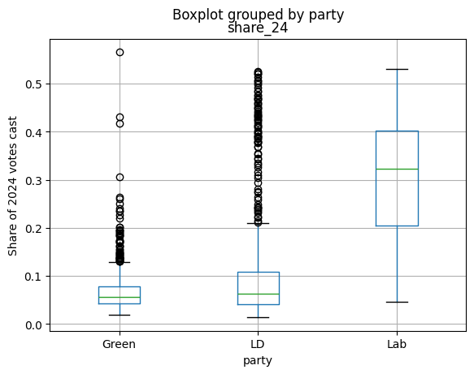

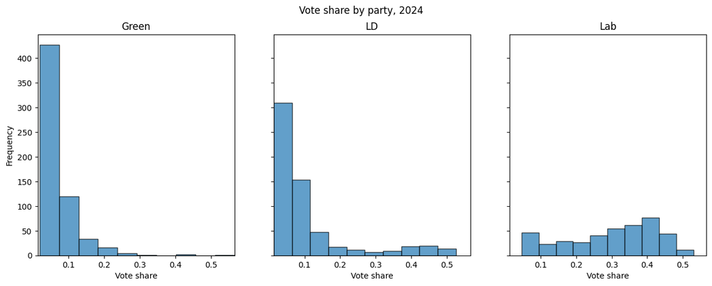

```python
# Create a boxplot for the 'share_24' variable, grouped by party
main_final.boxplot(column='share_24', by='party')
plt.ylabel('Share of 2024 votes cast')
plt.show()

# Determine global x-axis limits (min and max across all data)
x_min = main_final['share_24'].min()
x_max = main_final['share_24'].max()

# Create a set of histograms showing the same data
parties = main_final['party'].unique()
fig, axes = plt.subplots(1, len(parties), figsize=(15, 5), sharey=True)

# Create a histogram for each party
for ax, party in zip(axes, parties):
    data = main_final[main_final['party'] == party]['share_24']
    ax.hist(data, bins=10, edgecolor='black', alpha=0.7)
    ax.set_title(f"{party}")
    ax.set_xlabel('Vote share')
    ax.set_xlim(x_min, x_max)  # Set uniform x-axis limits
    if ax == axes[0]:
        ax.set_ylabel('Frequency')

# Adjust layout
plt.suptitle('Vote share by party, 2024')
plt.show()
```

#### Vote share by target seat status

Now the same, by whether or not the seat was targetted:

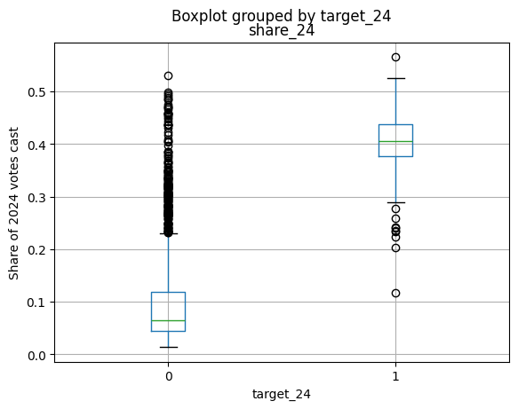

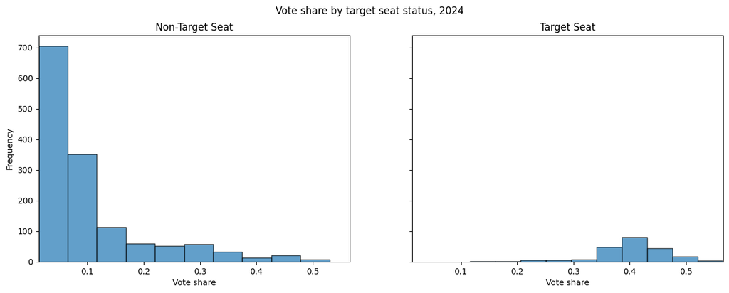

```python
# Create a boxplot for the 'share_24' variable, grouped by target seat status
main_final.boxplot(column='share_24', by='target_24')
plt.ylabel('Share of 2024 votes cast')
plt.show()

# Determine global x-axis limits (min and max across all data)
x_min = main_final['share_24'].min()
x_max = main_final['share_24'].max()

# Create a set of histograms showing the same data
target_status = main_final['target_24'].unique()
target_labels = {0: 'Non-Target Seat', 1: 'Target Seat'} # make binary values intelligble for labels
fig, axes = plt.subplots(1, len(target_status), figsize=(15, 5), sharey=True)

# Create a histogram for each target status
for ax, target in zip(axes, target_status):
    data = main_final[main_final['target_24'] == target]['share_24']
    ax.hist(data, bins=10, edgecolor='black', alpha=0.7)
    ax.set_title(target_labels[target])  # otherwise titles will be 0 and 1
    ax.set_xlabel('Vote share')
    ax.set_xlim(x_min, x_max)  # Set uniform x-axis limits
    if ax == axes[0]:
        ax.set_ylabel('Frequency')

# Adjust layout
plt.suptitle('Vote share by target seat status, 2024')
plt.show()
```

As before, we can see a very strong association of target seat status with vote share. The median campaign in a target seat achieved just over 40% of votes cast, whereas campaigns in non-target seats were so heavily right skewed that campaigns achieving more than ~25% of votes cast are treated by a boxplot as suspected outliers. (Remember that each row in the dataset is a unique combination of party and constituency, so 'target' indicates that the constituency in question was a target for the party in question.)

### Visualisations of Hypothesised Associations

In this section, I will consider the relationships that underpin these hypotheses. This assessment will be limited to visual consideration and tests of correlation, and will not take into account controls. In the section thereafter I will analyse them more fully, using regression analysis and taking into account control variables.

While not included in the regression analysis at the end of this document, I will assess the relationship with whether the campaign won, as well as just the vote share it attained, in preparation for future analysis on this point.

#### Winning 2024 campaigns by 2019 position

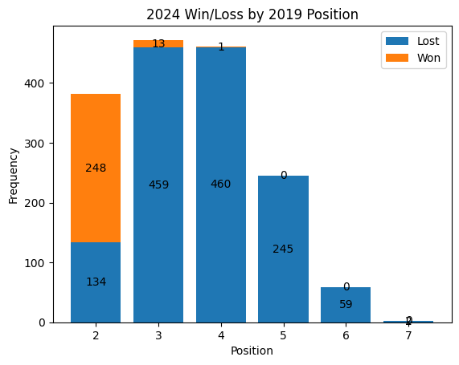

```python
# First up, winning 2024 campaigns by 2019 position.
wins_by_position = main_final.groupby(['position_19', 'won_24']).size().unstack(fill_value=0) # create temporary dataframe

# Create a stacked bar chart
x = wins_by_position.index
bar1 = plt.bar(x, wins_by_position[0], label='Lost')  # Bottom stack = lost
bar2 = plt.bar(x, wins_by_position[1], bottom=wins_by_position[0], label='Won')  # Top stack = won

# Add labels
plt.bar_label(bar1, label_type='center')
plt.bar_label(bar2, label_type='center')
plt.xlabel('Position')
plt.ylabel('Frequency')
plt.title('2024 Win/Loss by 2019 Position')
plt.legend()

# Show the plot
plt.show()
```

#### Winning 2024 campaigns by 2019 raw vote difference

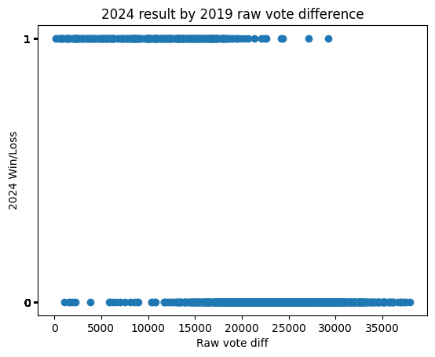

```python
# Second, winning 2024 campaigns by 2019 raw vote difference.
# Define x and y dimensions of scatter plot

x = main_final['raw_diff_19']
y = main_final['won_24']

plt.scatter(x, y)

# Add labels
plt.yticks(y, main_final['won_24'].values)
plt.ylabel('2024 Win/Loss')
plt.xlabel('Raw vote diff')
plt.title('2024 result by 2019 raw vote difference')

# Show the plot
plt.show()
```

We can see a negative association between winning in 2024 and the raw difference in votes won in 2019 (as measured by the difference between the votes won by winner and the number of votes won by the party in question).

#### Winning 2024 campaigns by 2019 percent vote difference

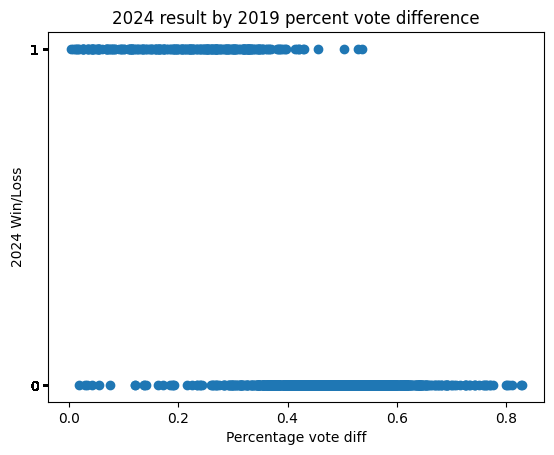

```python
# Third, winning 2024 campaigns by 2019 percent vote difference.

# Define x and y dimensions of scatter plot
x = main_final['pc_diff_19']
y = main_final['won_24']
plt.scatter(x, y)

# Add labels
plt.yticks(y, main_final['won_24'].values)
plt.ylabel('2024 Win/Loss')
plt.xlabel('Percentage vote diff')
plt.title('2024 result by 2019 percent vote difference')

plt.show()
```

As with raw vote difference, we can see an association between winning the 2024 election and the the percentage difference in votes won in 2019 (as measured by the difference between the votes won by winner and the number of votes won by the party in question), but the two distributions overlap to a very great extent. As such the association is present, but likely to be weak.

Contrary to expectations, the percentage vote difference looks to be slightly less strongly associated with winning in 2024 than the raw vote difference.

#### 2024 vote share by 2019 position

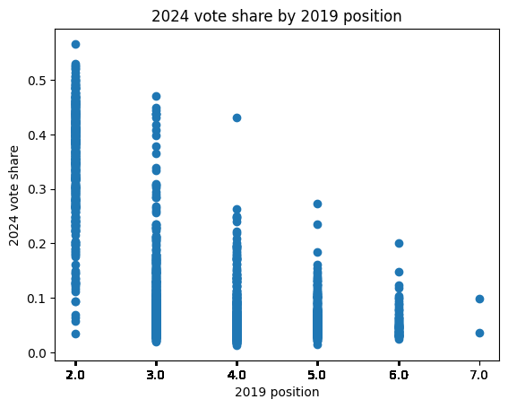

```python
# Fourth, 2024 vote share by 2019 position.

# Define x and y dimensions of scatter plot
x = main_final['position_19']
y = main_final['share_24']
plt.scatter(x, y)

# Add labels
plt.xticks(x, main_final['position_19'].values)
plt.ylabel('2024 vote share')
plt.xlabel('2019 position')
plt.title('2024 vote share by 2019 position')

plt.show()
```

Here we can see a very clear negative association between position in 2019 and vote share achieved in 2024. Since 2019 position is ranked from 1 = highest, this should be understood as indicating that a strong position in 2019 is associated with a larger share of the vote in 2024.

#### 2024 vote share by 2019 raw vote difference

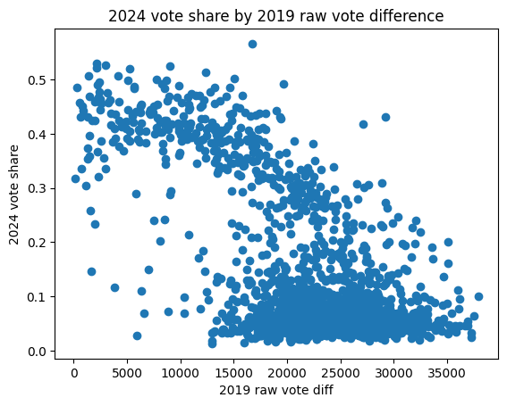

```python
# Fifth, 2024 vote share by 2019 raw vote difference.

# Define x and y dimensions of scatter plot
x = main_final['raw_diff_19']
y = main_final['share_24']
plt.scatter(x, y)

# Add labels
plt.ylabel('2024 vote share')
plt.xlabel('2019 raw vote diff')
plt.title('2024 vote share by 2019 raw vote difference')

plt.show()
```

The association here is more complicated. Overall there's a negative association between vote share in 2024 and raw difference in votes in 2019 (calculated between the winner and the party in question). That is, the higher the vote difference, the lower the vote share. However, there is a marked cluster of outcomes at or below 10% vote share in 2024 for vote differences in 2019 of around 13,000 to around 38,000. I suspect that non-linear aspect of this otherwise broadly linear relationship might disappear if the data were grouped by party, or another control variable.

#### 2024 vote share by 2019 percent vote difference

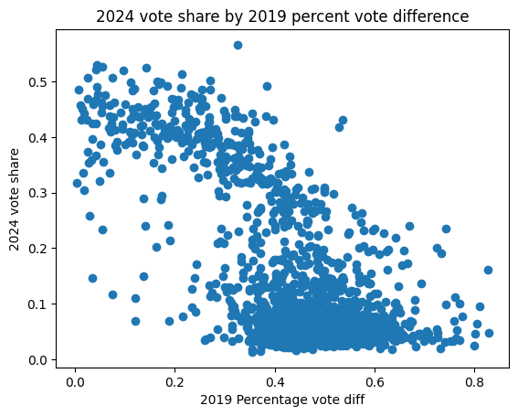

```python
# Sixth, 2024 vote share by 2019 percent vote difference.

# Define x and y dimensions of scatter plot
x = main_final['pc_diff_19']
y = main_final['share_24']
plt.scatter(x, y)

# Add labels
plt.ylabel('2024 vote share')
plt.xlabel('2019 Percentage vote diff')
plt.title('2024 vote share by 2019 percent vote difference')

plt.show()
```

Here we're again seeing a very similar association in the percent vote difference data as in the raw vote difference data.

#### Reflections on hypotheses prior to regression analysis

The visualisations above do not take into account any of the controls shortly to be applied to the data. With that in mind, we can see positive indications that the null hypothesis against H1 might be disproved: that is, it appears that each of the three independent variables seems likely to have a statistically discernible effect upon each of the dependent variables.

Thus far, however, there are no indications that the null hypothesis against H2 can be disproved: so far, raw vote share and percentage vote share have demonstrated very similar associations with both dependent variables.

Finally, initial indications are that position gained in 2019 bears a stronger association with both outcome variables than either of the vote difference measures. As such, it seems likely that the null hypothesis against H3 will be disproved.

However, no conclusions can be reached until we have conducted regression analysis with the contols taken into account.

## Statistical Analysis of Data

I'll proceed through two analyses here. First, using the dependent variable 'share_24', which measures the percentage of the vote won by each campaign in the relevant constituency. Second, using the dependent variable 'won_24' to indicate whether or not each campaign was successful in the constituency in question.

### OLS Regression Analysis: share_24

```python
# To run regressions, first we need to ensure that all relevant categorical variables are saved as dummies.
for_dummies = ['region_name', 'constituency_type', 'party', 'candidate_gender', 'former_mp', 'winner_19', 'target_24']

for_dummies
```

```
['region_name',
 'constituency_type',
 'party',
 'candidate_gender',
 'former_mp',
 'winner_19',
 'target_24']
```

```python
# Run pd.get_dummies on main_final columns that appear in the 'for_dummies' list

main_dummy = pd.get_dummies(main_final, columns=for_dummies, drop_first=True, dtype='int64') # We need to add drop_first to prevent ...
    # ... perfect prediction of dummy variables

main_dummy.columns
```

```
Index(['campaign_ID', 'constituency_ID', 'share_24', 'credible_candidates_24',
       'won_24', 'position_19', 'raw_diff_19', 'pc_diff_19',
       'region_name_East of England', 'region_name_London',
       'region_name_North East', 'region_name_North West',
       'region_name_Scotland', 'region_name_South East',
       'region_name_South West', 'region_name_Wales',
       'region_name_West Midlands', 'region_name_Yorkshire and The Humber',
       'constituency_type_County', 'party_LD', 'party_Lab',
       'candidate_gender_Male', 'candidate_gender_Non-binary', 'former_mp_Yes',
       'winner_19_Green', 'winner_19_LD', 'winner_19_Lab', 'winner_19_PC',
       'winner_19_SNP', 'target_24_1'],
      dtype='object')
```

```python
# Run ordinary least squares regression upon share_24

# First we need to define the dependent (y) variable and independent (X) variables, including controls
y = main_dummy['share_24']
X = main_dummy.drop(columns=['share_24', 'won_24','campaign_ID', 'constituency_ID']) # apart from these four, ...
    # ... everything in the dataset is a dependent variable (including controls)

# To prevent the regression being forced through the origin, we need to allow for an intercept constant
X = stats.add_constant(X)

# Now we can run the test and display the results
model = stats.OLS(y, X).fit()
print(model.summary())
```

```
                            OLS Regression Results
==============================================================================
Dep. Variable:               share_24   R-squared:                       0.804
Model:                            OLS   Adj. R-squared:                  0.801
Method:                 Least Squares   F-statistic:                     251.9
Date:                Fri, 03 Jan 2025   Prob (F-statistic):               0.00
Time:                        20:11:01   Log-Likelihood:                 2249.7
No. Observations:                1621   AIC:                            -4445.
Df Residuals:                    1594   BIC:                            -4300.
Df Model:                          26
Covariance Type:            nonrobust
========================================================================================================
                                           coef    std err          t      P>|t|      [0.025      0.975]
--------------------------------------------------------------------------------------------------------
const                                    0.3920      0.020     19.666      0.000       0.353       0.431
credible_candidates_24                   0.0030      0.002      1.370      0.171      -0.001       0.007
position_19                             -0.0532      0.003    -19.390      0.000      -0.059      -0.048
raw_diff_19                          -2.507e-06    8.3e-07     -3.019      0.003   -4.14e-06   -8.78e-07
pc_diff_19                              -0.0781      0.043     -1.813      0.070      -0.163       0.006
region_name_East of England              0.0067      0.007      0.941      0.347      -0.007       0.021
region_name_London                      -0.0166      0.008     -2.100      0.036      -0.032      -0.001
region_name_North East                  -0.0097      0.010     -0.963      0.336      -0.029       0.010
region_name_North West                  -0.0019      0.007     -0.258      0.796      -0.016       0.013
region_name_Scotland                    -0.0013      0.015     -0.089      0.929      -0.030       0.027
region_name_South East                   0.0020      0.007      0.301      0.763      -0.011       0.015
region_name_South West                   0.0075      0.007      1.041      0.298      -0.007       0.022
region_name_Wales                       -0.0321      0.010     -3.328      0.001      -0.051      -0.013
region_name_West Midlands               -0.0086      0.007     -1.161      0.246      -0.023       0.006
region_name_Yorkshire and The Humber    -0.0007      0.008     -0.095      0.924      -0.016       0.015
constituency_type_County                 0.0029      0.004      0.734      0.463      -0.005       0.011
party_LD                                -0.0680      0.005    -13.325      0.000      -0.078      -0.058
party_Lab                                0.0237      0.007      3.408      0.001       0.010       0.037
candidate_gender_Male                   -0.0003      0.003     -0.093      0.926      -0.007       0.006
candidate_gender_Non-binary             -0.0146      0.025     -0.582      0.560      -0.064       0.035
former_mp_Yes                            0.0430      0.014      3.055      0.002       0.015       0.071
winner_19_Green                          0.0101      0.044      0.230      0.818      -0.076       0.096
winner_19_LD                             0.0005      0.016      0.029      0.977      -0.031       0.032
winner_19_Lab                            0.0330      0.005      6.571      0.000       0.023       0.043
winner_19_PC                            -0.0815      0.026     -3.104      0.002      -0.133      -0.030
winner_19_SNP                            0.0510      0.014      3.527      0.000       0.023       0.079
target_24_1                              0.1478      0.007     22.626      0.000       0.135       0.161
==============================================================================
Omnibus:                      148.735   Durbin-Watson:                   2.340
Prob(Omnibus):                  0.000   Jarque-Bera (JB):              234.370
Skew:                           0.671   Prob(JB):                     1.28e-51
Kurtosis:                       4.292   Cond. No.                     6.81e+05
==============================================================================

Notes:
[1] Standard Errors assume that the covariance matrix of the errors is correctly specified.
[2] The condition number is large, 6.81e+05. This might indicate that there are
strong multicollinearity or other numerical problems.
```

Given note [2], I've sought some help from my good friend ChatGPT to understand how to reduce multicollinearity. He/she/it suggests VIF, as follows:

```python
from statsmodels.stats.outliers_influence import variance_inflation_factor

# Example: Calculating VIF for independent variables
X = main_dummy.drop(columns=['share_24', 'won_24', 'campaign_ID', 'constituency_ID'])  # Independent variables

# Add constant for intercept
X = stats.add_constant(X)

# Calculate VIF for each variable
vif_data = pd.DataFrame()
vif_data['Variable'] = X.columns
vif_data['VIF'] = [variance_inflation_factor(X.values, i) for i in range(X.shape[1])]

print(vif_data)
```

```
                                Variable         VIF
0                                  const  173.643640
1                 credible_candidates_24    1.310355
2                            position_19    4.123734
3                            raw_diff_19   15.364845
4                             pc_diff_19   16.393780
5            region_name_East of England    2.086856
6                     region_name_London    2.471906
7                 region_name_North East    1.573608
8                 region_name_North West    2.145294
9                   region_name_Scotland    7.799114
10                region_name_South East    2.527680
11                region_name_South West    2.063701
12                     region_name_Wales    1.842722
13             region_name_West Midlands    1.997414
14  region_name_Yorkshire and The Humber    1.963428
15              constituency_type_County    1.617342
16                              party_LD    2.658706
17                             party_Lab    3.995366
18                 candidate_gender_Male    1.053455
19           candidate_gender_Non-binary    1.015979
20                         former_mp_Yes    1.054416
21                       winner_19_Green    1.034138
22                          winner_19_LD    1.098021
23                         winner_19_Lab    2.014580
24                          winner_19_PC    1.111634
25                         winner_19_SNP    6.636683
26                           target_24_1    2.102604
```

Reviewing that output, and reviewing the p-values and effect sizes on the regression output, I have determined that:

1. raw_diff_19 and pc_diff_19 are creating high variance inflation, likely due to their strong multi-collinearity.
2. Since of those two, raw_diff_19 has a p-value of 0.003 and pc_diff_19 has a p-value of 0.07, I should remove the latter.
3. The other variable of concern in the VIF output is region_name_Scotland.
4. Since only two of the 11 regions have p-values of less than 0.05, I will remove the region variable also.

```python
# Removing pc_diff_19 and region_name_XYZ from the OLS regression.

# First, recreate for_dummies without region_name:

for_dummies = ['constituency_type', 'party', 'candidate_gender', 'former_mp', 'winner_19', 'target_24']

# Pass it through get_dummies to recreate for_dummies without region_name

main_dummy = pd.get_dummies(main_final, columns=for_dummies, drop_first=True, dtype='int64')

# Then add 'pc_diff_19' and 'region_name' to the exclusion list for Y:

y = main_dummy['share_24']
X = main_dummy.drop(columns=['region_name', 'pc_diff_19', 'share_24', 'won_24','campaign_ID', 'constituency_ID'])
```

```python
# Now re-run the OLS regression

X = stats.add_constant(X)
model = stats.OLS(y, X).fit()
print(model.summary())
```

```
                            OLS Regression Results
==============================================================================
Dep. Variable:               share_24   R-squared:                       0.800
Model:                            OLS   Adj. R-squared:                  0.798
Method:                 Least Squares   F-statistic:                     428.6
Date:                Fri, 03 Jan 2025   Prob (F-statistic):               0.00
Time:                        20:11:01   Log-Likelihood:                 2233.1
No. Observations:                1621   AIC:                            -4434.
Df Residuals:                    1605   BIC:                            -4348.
Df Model:                          15
Covariance Type:            nonrobust
===============================================================================================
                                  coef    std err          t      P>|t|      [0.025      0.975]
-----------------------------------------------------------------------------------------------
const                           0.3690      0.018     20.080      0.000       0.333       0.405
credible_candidates_24          0.0062      0.002      3.024      0.003       0.002       0.010
position_19                    -0.0540      0.003    -20.855      0.000      -0.059      -0.049
raw_diff_19                  -3.66e-06   3.19e-07    -11.462      0.000   -4.29e-06   -3.03e-06
constituency_type_County        0.0057      0.004      1.593      0.111      -0.001       0.013
party_LD                       -0.0682      0.005    -13.504      0.000      -0.078      -0.058
party_Lab                       0.0249      0.007      3.608      0.000       0.011       0.038
candidate_gender_Male          -0.0003      0.003     -0.096      0.924      -0.007       0.006
candidate_gender_Non-binary    -0.0206      0.025     -0.818      0.414      -0.070       0.029
former_mp_Yes                   0.0450      0.014      3.190      0.001       0.017       0.073
winner_19_Green                 0.0182      0.044      0.416      0.678      -0.068       0.104
winner_19_LD                   -0.0025      0.016     -0.161      0.872      -0.033       0.028
winner_19_Lab                   0.0241      0.004      5.351      0.000       0.015       0.033
winner_19_PC                   -0.1059      0.026     -4.139      0.000      -0.156      -0.056
winner_19_SNP                   0.0525      0.006      8.447      0.000       0.040       0.065
target_24_1                     0.1512      0.007     23.254      0.000       0.138       0.164
==============================================================================
Omnibus:                      167.365   Durbin-Watson:                   2.288
Prob(Omnibus):                  0.000   Jarque-Bera (JB):              273.222
Skew:                           0.723   Prob(JB):                     4.68e-60
Kurtosis:                       4.398   Cond. No.                     6.61e+05
==============================================================================

Notes:
[1] Standard Errors assume that the covariance matrix of the errors is correctly specified.
[2] The condition number is large, 6.61e+05. This might indicate that there are
strong multicollinearity or other numerical problems.
```

```python
# We still have a very large condition number, so I'm going to run VIF again:

from statsmodels.stats.outliers_influence import variance_inflation_factor

# Example: Calculating VIF for independent variables
X = main_dummy.drop(columns=['region_name', 'pc_diff_19','share_24', 'won_24', 'campaign_ID', 'constituency_ID'])  # Independent variables

# Add constant for intercept
X = stats.add_constant(X)

# Calculate VIF for each variable
vif_data = pd.DataFrame()
vif_data['Variable'] = X.columns
vif_data['VIF'] = [variance_inflation_factor(X.values, i) for i in range(X.shape[1])]

print(vif_data)
```

```
                       Variable         VIF
0                         const  145.543366
1        credible_candidates_24    1.098922
2                   position_19    3.634330
3                   raw_diff_19    2.242385
4      constituency_type_County    1.308482
5                      party_LD    2.571784
6                     party_Lab    3.890985
7         candidate_gender_Male    1.043834
8   candidate_gender_Non-binary    1.008762
9                 former_mp_Yes    1.045721
10              winner_19_Green    1.022447
11                 winner_19_LD    1.044471
12                winner_19_Lab    1.593302
13                 winner_19_PC    1.040787
14                winner_19_SNP    1.212373
15                  target_24_1    2.055994
```

Ok, while the condition number is still high, only the intercept has a high VIF, so I'm going to crack on at this point, because I judge that it would be more harmful to remove the intercept than to try to prevent multi-collinearity.

I will, however, make one more change to the data. The intercept and slope values for raw_diff_19 are hard to interpret because its units are several orders of magnitude greater than the other units in use (such as position, which is single digit number between 2 and 7). So, I will add a variable called raw_diff_19_0000, which will be the same number expressed in tens of thousands of votes rather than in single votes.

```python
# Add raw_diff_19_0000 to main_dummy

main_dummy['raw_diff_19_0000'] = main_dummy['raw_diff_19'] / 10000

# Add raw_diff_19 to the exclusions list:

y = main_dummy['share_24']
X = main_dummy.drop(columns=['region_name', 'raw_diff_19', 'pc_diff_19', 'share_24', 'won_24','campaign_ID', 'constituency_ID'])
```

```python
# And run the regression again. Third time's a charm!
X = stats.add_constant(X)
model = stats.OLS(y, X).fit()
print(model.summary())
```

```
                            OLS Regression Results
==============================================================================
Dep. Variable:               share_24   R-squared:                       0.800
Model:                            OLS   Adj. R-squared:                  0.798
Method:                 Least Squares   F-statistic:                     428.6
Date:                Fri, 03 Jan 2025   Prob (F-statistic):               0.00
Time:                        20:11:01   Log-Likelihood:                 2233.1
No. Observations:                1621   AIC:                            -4434.
Df Residuals:                    1605   BIC:                            -4348.
Df Model:                          15
Covariance Type:            nonrobust
===============================================================================================
                                  coef    std err          t      P>|t|      [0.025      0.975]
-----------------------------------------------------------------------------------------------
const                           0.3690      0.018     20.080      0.000       0.333       0.405
credible_candidates_24          0.0062      0.002      3.024      0.003       0.002       0.010
position_19                    -0.0540      0.003    -20.855      0.000      -0.059      -0.049
constituency_type_County        0.0057      0.004      1.593      0.111      -0.001       0.013
party_LD                       -0.0682      0.005    -13.504      0.000      -0.078      -0.058
party_Lab                       0.0249      0.007      3.608      0.000       0.011       0.038
candidate_gender_Male          -0.0003      0.003     -0.096      0.924      -0.007       0.006
candidate_gender_Non-binary    -0.0206      0.025     -0.818      0.414      -0.070       0.029
former_mp_Yes                   0.0450      0.014      3.190      0.001       0.017       0.073
winner_19_Green                 0.0182      0.044      0.416      0.678      -0.068       0.104
winner_19_LD                   -0.0025      0.016     -0.161      0.872      -0.033       0.028
winner_19_Lab                   0.0241      0.004      5.351      0.000       0.015       0.033
winner_19_PC                   -0.1059      0.026     -4.139      0.000      -0.156      -0.056
winner_19_SNP                   0.0525      0.006      8.447      0.000       0.040       0.065
target_24_1                     0.1512      0.007     23.254      0.000       0.138       0.164
raw_diff_19_0000               -0.0366      0.003    -11.462      0.000      -0.043      -0.030
==============================================================================
Omnibus:                      167.365   Durbin-Watson:                   2.288
Prob(Omnibus):                  0.000   Jarque-Bera (JB):              273.222
Skew:                           0.723   Prob(JB):                     4.68e-60
Kurtosis:                       4.398   Cond. No.                         179.
==============================================================================

Notes:
[1] Standard Errors assume that the covariance matrix of the errors is correctly specified.
```

First, we can note that the warning regarding multi-collinearity disappeared with the change from raw_diff_19 to raw_diff_19_0000. These results are those more reliable than the previous sets above.

Second, the adjusted R-squared is 0.798, indicating that the model accounts for nearly 80% of the variance found in the data. With an f-statistic of 428.6 and p-value of 0.000, we can be confident the model overall comprises a strong set of explanatory relationships.

Reviewing this output allows us to conclude (with respect to H1) that both the position in 2019 and raw difference in votes in 2019 (calculated in the 10,000s) have statistically significant effects upon a campaign's share of votes in 2024.

Both of these values are lower than might be expected: given that a constituency tends to have around 50,0000 to 70,000 votes cast, I would expect a 10,000 vote difference in 2019 to result in a loss of more than ~1,800 to ~2,500 votes in 2024 - that is, 3.66% of 50k to 70k votes. However, both effects are statistically significant.

Excellent! Now, since two of our hypotheses involve an independent variable that was just removed from the study, let's run that regression again with percentage vote difference rather than raw.

```python
# Remove pc_diff_19 from exclusions list, and add raw_diff_19_0000:

y = main_dummy['share_24']
X = main_dummy.drop(columns=['region_name', 'raw_diff_19', 'raw_diff_19_0000', 'share_24', 'won_24','campaign_ID', 'constituency_ID'])
```

```python
# Now to run the regression again with pc_diff_19 rather than raw_diff_19_0000.
X = stats.add_constant(X)
model = stats.OLS(y, X).fit()
print(model.summary())
```

```
                            OLS Regression Results
==============================================================================
Dep. Variable:               share_24   R-squared:                       0.799
Model:                            OLS   Adj. R-squared:                  0.797
Method:                 Least Squares   F-statistic:                     426.2
Date:                Fri, 03 Jan 2025   Prob (F-statistic):               0.00
Time:                        20:11:01   Log-Likelihood:                 2229.5
No. Observations:                1621   AIC:                            -4427.
Df Residuals:                    1605   BIC:                            -4341.
Df Model:                          15
Covariance Type:            nonrobust
===============================================================================================
                                  coef    std err          t      P>|t|      [0.025      0.975]
-----------------------------------------------------------------------------------------------
const                           0.3676      0.018     19.887      0.000       0.331       0.404
credible_candidates_24          0.0047      0.002      2.272      0.023       0.001       0.009
position_19                    -0.0519      0.003    -20.005      0.000      -0.057      -0.047
pc_diff_19                     -0.1840      0.017    -11.122      0.000      -0.216      -0.152
constituency_type_County        0.0028      0.004      0.771      0.441      -0.004       0.010
party_LD                       -0.0648      0.005    -12.944      0.000      -0.075      -0.055
party_Lab                       0.0285      0.007      4.165      0.000       0.015       0.042
candidate_gender_Male        9.339e-05      0.003      0.029      0.977      -0.006       0.006
candidate_gender_Non-binary    -0.0149      0.025     -0.589      0.556      -0.064       0.035
former_mp_Yes                   0.0450      0.014      3.184      0.001       0.017       0.073
winner_19_Green                 0.0012      0.044      0.028      0.977      -0.085       0.087
winner_19_LD                   -0.0073      0.016     -0.460      0.645      -0.038       0.024
winner_19_Lab                   0.0284      0.004      6.342      0.000       0.020       0.037
winner_19_PC                   -0.1069      0.026     -4.164      0.000      -0.157      -0.057
winner_19_SNP                   0.0534      0.006      8.574      0.000       0.041       0.066
target_24_1                     0.1525      0.007     23.437      0.000       0.140       0.165
==============================================================================
Omnibus:                      152.961   Durbin-Watson:                   2.311
Prob(Omnibus):                  0.000   Jarque-Bera (JB):              242.643
Skew:                           0.683   Prob(JB):                     2.04e-53
Kurtosis:                       4.313   Cond. No.                         168.
==============================================================================

Notes:
[1] Standard Errors assume that the covariance matrix of the errors is correctly specified.
```

Happily, pc_diff_19 does indeed have a statistically discernible effect on the dependent variable. We can surmise that the appearance of no such relationship resulted from the collinearity with raw_diff_19.

To interpret the slope on pd_diff_19, let's remind ourselves of its distribution.

```
count    1621.000000
mean        0.439244
std         0.142220
min         0.002696
25%         0.377118
50%         0.455060
75%         0.533829
max         0.828956
Name: pc_diff_19, dtype: float64
```

```
<function matplotlib.pyplot.show(close=None, block=None)>
```

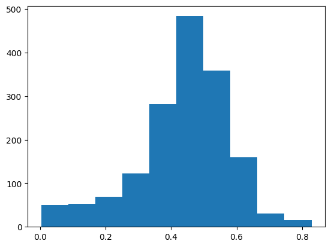

```python
print(main_dummy['pc_diff_19'].describe())
plt.hist(main_dummy['pc_diff_19'])
plt.show
```

For every increase of 1 (i.e. 100%) in percentage difference between the candidate and the winner, the model expects an 18.4 percentage point reduction in the 2024 vote share. Since the median of pc_diff_19 is 0.455, we can expect that it accounts for very roughly 8.4 percentage points in variation in 2024 vote share in the median seat.

Since H2 requires us to compare the explanatory values of percentage difference vs raw difference, let's bring up the distribution for raw vote difference also.

```
count     1621.000000
mean     21761.291178
std       7144.802826
min        127.000000
25%      18209.000000
50%      22655.000000
75%      26608.000000
max      37900.000000
Name: raw_diff_19, dtype: float64
```

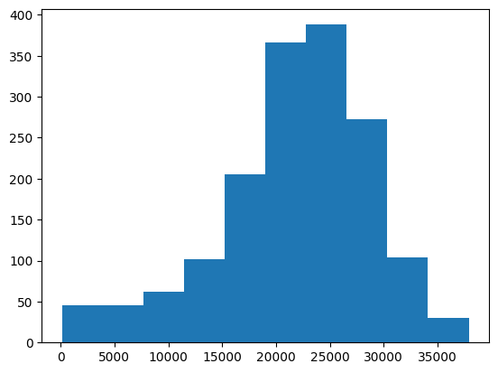

```python
plt.hist(main_dummy['raw_diff_19'])
plt.show

print(main_dummy['raw_diff_19'].describe())
```

We established that percentage vote difference between the winner and the candidate in 2019 resulted in an approximately 8.4 percentage point difference in the campaign's 2024 vote share. How does raw vote difference compare to that?

In the distribution above, we can see that the median raw vote difference is 22,655. Since we established in the previous regression analysis that a change in 10,000 votes of difference in 2019 resulted in a change of vote share in 2024 of 3.66, we can surmise that in the median seat the raw vote difference in 2019 resulted in a 2024 change in vote share of (2.2655 * 3.66 =) ~8.3 percentage point difference. Almost exactly the same as the effect of the percentage vote difference.

Note: I do not claim that this latter analysis reaches the standard for statistical significance. It does, however, add some credence to the possibility that we cannot meaningfully distinguish between the explanatory value of percentage difference and raw difference in vote share. It may be that this results from the increased standardisation in size of constituencies in the UK for the 2024 elections (although further analysis will be required to assess that, including of variance in turnout across constituencies.)

#### Support for Hypotheses

With respect to the outcome variable 'share_24', we can conclude that:

1. We *can* reject the null hypothesis associated with H1.
- H1. All three selected factors will be statistically discernible predictors of the outcome of a campaign.
  - H0. Null Hypothesis: one or more of the three selected factors will *not* be a statistically discerinble predictor of the outcome of the campaign.
2. We *cannot* definitively reject the null hypothesis associated with H2.
- H2. Difference in 2019 percentage vote share will be a stronger predictor of the campaign outcome than difference in 2019 number of votes.
  - H0. Null Hypothesis: difference in 2019 percentage vote share will *not* be a stronger predictor of the campaign outcome than difference in 2019 number of votes.
3. We *cannot* definitively reject the null hypothesis associated with H3, because the units of measurement between 'position achieved in 2019' and either measure of vote share selected are not comparable. This is a clear failure of study design!
- H3. Whether the campaign achieved second place in the 2019 election will be a stronger predictor of the 2024 campaign outcome than either other factor.
  - H0. Null hypothesis: whether the campaign achieved second place in the 2019 election will *not* be a stronger predictor of the 2024 campaign outcome than either other factor.

Despite the inability to reject the null hypothesis for H3, however, we can establish an equivalence that may be of us in selecting target seats. That is, what difference in vote share is equivalent to a difference of 1 in the position rankings?

Similarly, we know that a percentage difference of 1 (i.e. 100%) explained a 2024 vote share difference of 18.44 percentage points. As such, we can conclude that a percentage vote difference of (1 / 18.44% / 5.2% = ) 28.20 in 2019 is broadly approximately equivalent in terms of explanatory value to one place in the rankings in 2019.

## Conclusions

The analysis above has established that all three measures of election results used in rules of thumb for selecting target seats have statistically discernible associations with vote share, when examined in the context of the 2024 UK general election.

It has also been demonstrated that, with respect to the UK General Election, there is insufficient evidence to conclude that percentage vote difference and raw vote difference are significantly different in their explanatory power in this respect.

While the study design did not allow us to determine whether a party's position in 2019 in a given constituency had more or less predictive power than either measure of vote difference between that party and the winner in that constituency in 2019, we were able to develop a measure of approximate equivalence that could be of use in selecting target seats. Namely, that:

1. one difference in position in the 2019 rankings was equivalent to ~14,500 difference in raw votes
2. and to ~28% in percentage vote difference.

Conversely, whether or not a campaign took place in what StopTheTories.vote considered to be a target seat seems to have explained more variation than any other predictor: a difference of 15 percentage points.

## Next Steps

The immediate next step in analysis is to apply the same approach to a logistic regression over won_24, to determine the predictive power over the likelihood of winning.

Potential future directions thereafter include:

1. expanding this analysis over a longer time series;
2. adding additional control variables, such as political party fundraising, number of local councillors, and degree of change in constituency boundaries;
3. exploring the surprising finding that gender of candidate and urban/rural nature of seat had no apparent predictive power.